# Relative fitness in a field setting - Figure 4 (Evolution MS)

####glmer.nb: Negative Binomial Here I tried fitting my data to a negative binomial distribution, but my data are non-integer, so this model won’t work. Let’s try building a model and fitting it to a Beta distribution which can deal with non-integers (between 0 and 1), first without a link function. Check it with DHARMa, and if it doesn’t look good, then fit it to a Beta distribution with a logit link function.

fullmodel<-glmer.nb(Growth.Rate)~ #Response variable: growth rate Habitat*Treatment+ #Fixed effects and their interactions(*) (1|Site)+(1|Block), #Random effect with random intercept only data=mydata) #Dataframe

Generalized linear mixed-effects model (GLMM) with a negative binomial distribution is part of the lme4 package, which is commonly used for fitting various types of mixed-effects models.

The negative binomial distribution is often used to model count data that exhibit overdispersion, meaning the variance is greater than the mean. This distribution is useful when the assumption of a Poisson distribution (equal mean and variance) is violated.

The glmer.nb() function specifically fits a GLMM with a negative binomial distribution by taking into account both fixed effects (predictors) and random effects (grouping factors). It allows for the modeling of correlated data where observations within the same group may be more similar to each other than to observations from other groups.

####glmm: Beta Distribution Turns out this was also not helpful because beta distributions are for proportions, which this is not.But I’ll keep this here for future reference.

fullmodel<-glmmTMB(Growth.Rate~ #Response variable: growth rate Habitat*Treatment+ #Fixed effects and their interactions (*) (1|Site)+(1|Block), #Random effect with random intercept only family=beta_family(), #Specify the family as beta_family (for beta regression) data=growth_mydata) #Dataframe

Generalized linear mixed-effects models (GLMMs) using a template model builder (TMB) framework. GLMMs are a type of statistical model that extends generalized linear models (GLMs) to account for correlated or clustered data, hierarchical structures, and random effects. They are suitable for analyzing data with non-normal response variables or data that violate the assumptions of traditional linear models.

The glmmTMB() function allows you to specify a GLMM using a formula syntax similar to GLMs. It supports various families of distributions (e.g., Gaussian, binomial, Poisson) and link functions, allowing for the analysis of different types of response variables. Additionally, it allows for the inclusion of both fixed effects (predictors) and random effects (grouping factors) to capture the variability within and between groups.

The TMB framework implemented in glmmTMB utilizes efficient algorithms for model fitting and parameter estimation. It offers computational advantages, making it particularly useful for large datasets or models with complex structures. The package also provides functionality for handling zero-inflation, overdispersion, and handling non-Gaussian response distributions.

###Best Model

```r
growth_fullmodel2<-lmer(sqrt(Growth.Rate)~
                          Habitat*Treatment+
                          (1|Site)+
                          (1|Block),
                        data=growth_mydata)
summary(growth_fullmodel2)
```

```
Linear mixed model fit by REML. t-tests use Satterthwaite's method ['lmerModLmerTest']
Formula: sqrt(Growth.Rate) ~ Habitat * Treatment + (1 | Site) + (1 | Block)
   Data: growth_mydata

REML criterion at convergence: -271.1

Scaled residuals:
     Min       1Q   Median       3Q      Max
-2.75170 -0.70742  0.04675  0.72993  2.37882

Random effects:
 Groups   Name        Variance  Std.Dev.
 Block    (Intercept) 0.0009601 0.03099
 Site     (Intercept) 0.0001233 0.01110
 Residual             0.0154163 0.12416
Number of obs: 226, groups:  Block, 10; Site, 8

Fixed effects:
                                            Estimate Std. Error         df t value Pr(>|t|)
(Intercept)                                 0.274343   0.022973  60.272607   11.94   <2e-16 ***
HabitatVegetated                            0.026520   0.027903 210.393040    0.95    0.343
TreatmentBiomass Removal                    0.297160   0.025038 214.982016   11.87   <2e-16 ***
HabitatVegetated:TreatmentBiomass Removal  -0.008642   0.034637 209.501173   -0.25    0.803
---
Signif. codes:  0 ‘***’ 0.001 ‘**’ 0.01 ‘*’ 0.05 ‘.’ 0.1 ‘ ’ 1

Correlation of Fixed Effects:
            (Intr) HbttVg TrtmBR
HabittVgttd -0.634
TrtmntBmssR -0.723  0.581
HbttVgt:TBR  0.509 -0.804 -0.711
```

#Survival Analysis This code uses NumDaysAlive data with Habitat (roadside and vegetated) and Treatment in a Cox proportional hazards model to assess survival. Information here: https://cran.r-project.org/web/packages/coxme/vignettes/coxme.pdf. “Surv” creates a survival object to combine the days column (NumDaysAlive) and the reproductive censor column (ReproductionCensor) to be used as a response variable in a model formula. The model follows the same syntax as linear models (lm, lmer, etc). Fixed effects: “var1 * var2” will give you the interaction term and the individual variables: so “var1 + var2 + var1:var2”. To add random effects, type “+ (1|random effect)”.

##Histograms

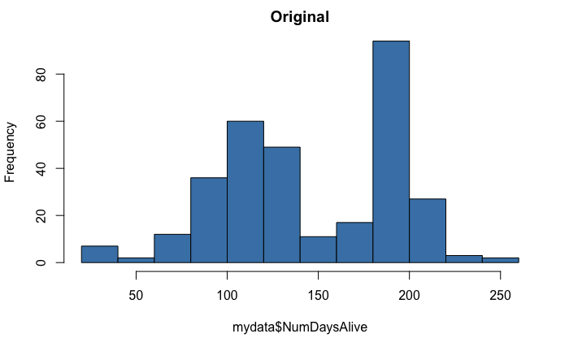

```r
#Number of Days Alive - All data
hist(mydata$NumDaysAlive,
     col='steelblue',
     main='Original')
```

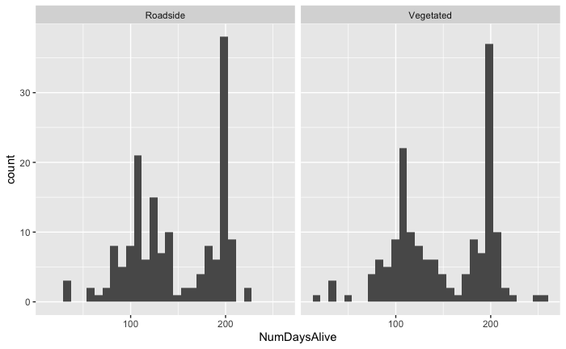

```r
#Number of Days Alive - By Habitat
ggplot(mydata,
       aes(x=NumDaysAlive))+
  geom_histogram()+
  facet_wrap(vars(Habitat)) #Here we see that both Habitats have the same bi-modal distribution.
```

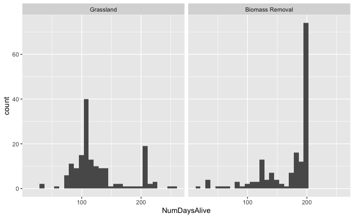

```r
#Number of Days Alive - By Treatment
ggplot(mydata,
       aes(x=NumDaysAlive))+
  geom_histogram()+
  facet_wrap(vars(Treatment))
```

Assumptions for cox models: https://www.theanalysisfactor.com/assumptions-cox-regression/

###Simple Model Start by making a simple model with no random effects. This will be compared to the full model with random effects.

```r
cox_simplemodel1<-coxph(Surv(NumDaysAlive,
                             CensorReproduction)~ #Only those that survived to bud are included
                          Habitat*Treatment,
                        data=mydata)
summary(cox_simplemodel1)
```

```
Call:
coxph(formula = Surv(NumDaysAlive, CensorReproduction) ~ Habitat *
    Treatment, data = mydata)

  n= 320, number of events= 160

                                             coef exp(coef) se(coef)      z Pr(>|z|)
HabitatVegetated                          -0.5771    0.5615   0.3317 -1.740   0.0819 .
TreatmentBiomass Removal                   1.6992    5.4694   0.3472  4.894 9.89e-07 ***
HabitatVegetated:TreatmentBiomass Removal  0.5756    1.7782   0.3781  1.523   0.1279
---
Signif. codes:  0 ‘***’ 0.001 ‘**’ 0.01 ‘*’ 0.05 ‘.’ 0.1 ‘ ’ 1

                                          exp(coef) exp(-coef) lower .95 upper .95
HabitatVegetated                             0.5615     1.7809    0.2931     1.076
TreatmentBiomass Removal                     5.4694     0.1828    2.7694    10.802
HabitatVegetated:TreatmentBiomass Removal    1.7782     0.5624    0.8476     3.731

Concordance= 0.586  (se = 0.035 )
Likelihood ratio test= 67.19  on 3 df,   p=2e-14
Wald test            = 43.68  on 3 df,   p=2e-09
Score (logrank) test = 53.87  on 3 df,   p=1e-11
```

```r
print(cox_simplemodel1)
```

```
Call:
coxph(formula = Surv(NumDaysAlive, CensorReproduction) ~ Habitat *
    Treatment, data = mydata)

                                             coef exp(coef) se(coef)      z        p
HabitatVegetated                          -0.5771    0.5615   0.3317 -1.740   0.0819
TreatmentBiomass Removal                   1.6992    5.4694   0.3472  4.894 9.89e-07
HabitatVegetated:TreatmentBiomass Removal  0.5756    1.7782   0.3781  1.523   0.1279

Likelihood ratio test=67.19  on 3 df, p=1.707e-14
n= 320, number of events= 160
```

```r
predict(cox_simplemodel1)
```

```
  [1]  1.6991676  1.6991676  1.6991676  1.6991676  1.6991676  1.6991676  1.6991676  1.6991676  1.6991676
 [10]  1.6991676  1.6991676  1.6991676  1.6991676  1.6991676  1.6991676  1.6991676  1.6991676  1.6991676
 [19]  1.6991676  1.6991676  1.6991676  1.6991676  1.6991676  1.6991676  1.6991676  1.6991676  1.6991676
 [28]  1.6991676  1.6991676  1.6991676  1.6991676  1.6991676  1.6991676  1.6991676  1.6991676  1.6991676
 [37]  1.6991676  1.6991676  1.6991676  1.6991676  1.6991676  1.6991676  1.6991676  1.6991676  1.6991676
 [46]  1.6991676  1.6991676  1.6991676  1.6991676  1.6991676  1.6991676  1.6991676  1.6991676  1.6991676
 [55]  1.6991676  1.6991676  1.6991676  1.6991676  1.6991676  1.6991676  1.6991676  1.6991676  1.6991676
 [64]  1.6991676  1.6991676  1.6991676  1.6991676  1.6991676  1.6991676  1.6991676  1.6991676  1.6991676
 [73]  1.6991676  1.6991676  1.6991676  1.6991676  1.6991676  1.6991676  1.6991676  1.6991676  1.6976849
 [82]  1.6976849  1.6976849  1.6976849  1.6976849  1.6976849  1.6976849  1.6976849  1.6976849  1.6976849
 [91]  1.6976849  1.6976849  1.6976849  1.6976849  1.6976849  1.6976849  1.6976849  1.6976849  1.6976849
[100]  1.6976849  1.6976849  1.6976849  1.6976849  1.6976849  1.6976849  1.6976849  1.6976849  1.6976849
[109]  1.6976849  1.6976849  1.6976849  1.6976849  1.6976849  1.6976849  1.6976849  1.6976849  1.6976849
[118]  1.6976849  1.6976849  1.6976849  1.6976849  1.6976849  1.6976849  1.6976849  1.6976849  1.6976849
[127]  1.6976849  1.6976849  1.6976849  1.6976849  1.6976849  1.6976849  1.6976849  1.6976849  1.6976849
```

[output cut: 21 more lines]

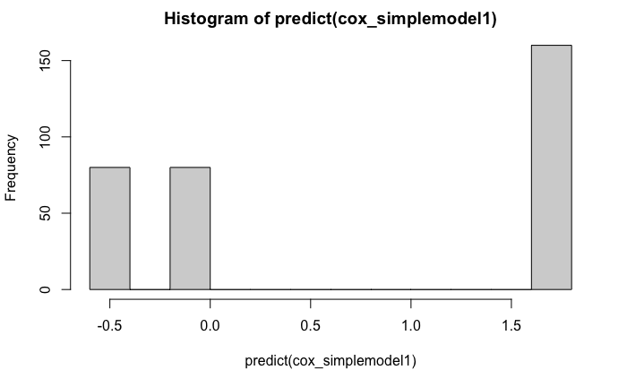

```r
hist(predict(cox_simplemodel1))
```

###Full Model 1 - coxme Now make a full model using random effects

```r
cox_fullmodel1<-coxme(Surv(NumDaysAlive,CensorReproduction)~
                        Habitat*Treatment+
                        (1|Site)+
                        (1|Block),
                      data=mydata)
summary(cox_fullmodel1)
```

```
Cox mixed-effects model fit by maximum likelihood
  Data: mydata
  events, n = 160, 320
  Iterations= 7 47
                    NULL Integrated    Fitted
Log-likelihood -676.4353  -623.8723 -606.6463

                   Chisq   df p    AIC   BIC
Integrated loglik 105.13  5.0 0  95.13 79.75
 Penalized loglik 139.58 13.3 0 112.98 72.07

Model:  Surv(NumDaysAlive, CensorReproduction) ~ Habitat * Treatment +      (1 | Site) + (1 | Block)
Fixed coefficients
                                                coef exp(coef)  se(coef)     z       p
HabitatVegetated                          -0.4439054 0.6415261 0.3492953 -1.27 2.0e-01
TreatmentBiomass Removal                   1.9078245 6.7384132 0.3776068  5.05 4.4e-07
HabitatVegetated:TreatmentBiomass Removal  0.5337000 1.7052300 0.3927154  1.36 1.7e-01

Random effects
 Group Variable  Std Dev    Variance
 Site  Intercept 0.15813763 0.02500751
 Block Intercept 0.81215553 0.65959660
```

```r
print(cox_fullmodel1)
```

```
Cox mixed-effects model fit by maximum likelihood
  Data: mydata
  events, n = 160, 320
  Iterations= 7 47
                    NULL Integrated    Fitted
Log-likelihood -676.4353  -623.8723 -606.6463

                   Chisq   df p    AIC   BIC
Integrated loglik 105.13  5.0 0  95.13 79.75
 Penalized loglik 139.58 13.3 0 112.98 72.07

Model:  Surv(NumDaysAlive, CensorReproduction) ~ Habitat * Treatment +      (1 | Site) + (1 | Block)
Fixed coefficients
                                                coef exp(coef)  se(coef)     z       p
HabitatVegetated                          -0.4439054 0.6415261 0.3492953 -1.27 2.0e-01
TreatmentBiomass Removal                   1.9078245 6.7384132 0.3776068  5.05 4.4e-07
HabitatVegetated:TreatmentBiomass Removal  0.5337000 1.7052300 0.3927154  1.36 1.7e-01

Random effects
 Group Variable  Std Dev    Variance
 Site  Intercept 0.15813763 0.02500751
 Block Intercept 0.81215553 0.65959660
```

```r
predict(cox_fullmodel1)
```

```
  [1]  3.570525077  1.861119361  1.651958824  1.760682078  3.024951374  2.034175698  2.020368065  1.892909583
  [9]  1.145348506  1.050083552  3.525864067  1.816458351  1.607297813  1.716021068  2.980290364  1.989514688
 [17]  1.975707055  1.848248573  1.100687496  1.005422542  3.405466903  1.696061187  1.486900650  1.595623904
 [25]  2.859893200  1.869117524  1.855309892  1.727851409  0.980290332  0.885025378  3.506920692  1.797514976
 [33]  1.588354439  1.697077693  2.961346989  1.970571313  1.956763680  1.829305198  1.081744121  0.986479167
 [41]  3.424679661  1.715273945  1.506113408  1.614836662  2.879105958  1.888330282  1.874522649  1.747064167
 [49]  0.999503090  0.904238136  3.610092277  1.900686561  1.691526024  1.800249278  3.064518574  2.073742898
 [57]  2.059935265  1.932476783  1.184915706  1.089650752  3.363249770  1.653844054  1.444683517  1.553406771
 [65]  2.817676067  1.826900391  1.813092758  1.685634276  0.938073199  0.842808245  3.410300187  1.700894471
 [73]  1.491733934  1.600457188  2.864726484  1.873950808  1.860143175  1.732684693  0.985123616  0.889858662
 [81]  3.660319680  1.950913964  1.741753427  1.850476681  3.114745977  2.123970301  2.110162668  1.982704186
 [89]  1.235143109  1.139878155  3.615658670  1.906252954  1.697092417  1.805815671  3.070084967  2.079309291
 [97]  2.065501658  1.938043176  1.190482099  1.095217145  3.495261507  1.785855790  1.576695253  1.685418507
[105]  2.949687803  1.958912127  1.945104495  1.817646012  1.070084935  0.974819981  3.596715295  1.887309579
[113]  1.678149042  1.786872296  3.051141592  2.060365916  2.046558284  1.919099801  1.171538724  1.076273770
```

[output cut: 25 more lines]

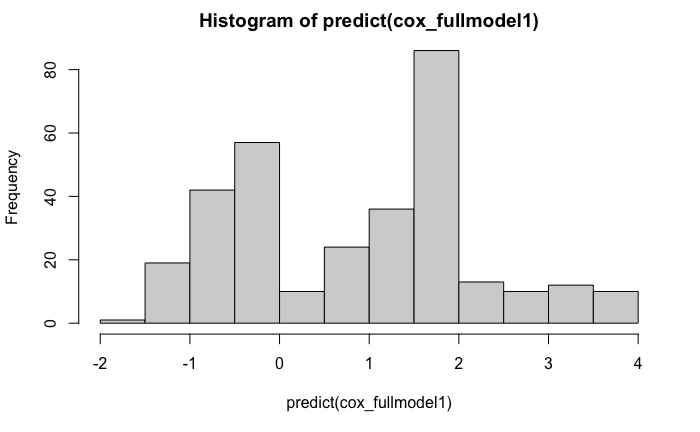

```r
hist(predict(cox_fullmodel1))
```

Now we can compare the models to see which model is best, in this case it is fullmodel1.

```r
anova(cox_simplemodel1,cox_fullmodel1)
```

```
Analysis of Deviance Table
 Cox model: response is  Surv(NumDaysAlive, CensorReproduction)
 Model 1: ~Habitat * Treatment
 Model 2: ~Habitat * Treatment + (1 | Site) + (1 | Block)
   loglik  Chisq Df P(>|Chi|)
1 -642.84
2 -623.87 37.938  2  5.78e-09 ***
---
Signif. codes:  0 ‘***’ 0.001 ‘**’ 0.01 ‘*’ 0.05 ‘.’ 0.1 ‘ ’ 1
```